# Spotify Top 100 Yearly Playlist Analysis

Wesley Gardiner

9/9/2021

## Wesley, Why?

Every year Spotify comes out with our top 100 songs. Since I’ve been using Spotify from some time now, I have a couple playlists built up. I always wondered how my music taste has changed throughout the years. Wielding Spotify’s API and being able to access different [Audio Features](https://benanne.github.io/2014/08/05/spotify-cnns.html) I thought it might be worth checking out.

Check out the [GitHub repo](https://github.com/wesley4546/spotify_playlist_analysis)

```r
library(tidyverse)
library(ggdist) # Nice visualizations
library(patchwork) # Easy plot combinations
```

After using python to interact with Spotify (see [Github](https://github.com/wesley4546/spotify_playlist_analysis/blob/main/spotifyapi.py)) I downloaded my data and [cleaned it up.](https://github.com/wesley4546/spotify_playlist_analysis/blob/main/cleaning_script.R)

## Let’s start coding

```r
filepath_to_data <- here::here("content",
                               "post",
                               "2021-09-09-spotify-yearly-playlist",
                               "data")

playlist_2016 <- read_csv(here::here(filepath_to_data,
                                     "clean_2016_playlist.csv"))
playlist_2017 <- read_csv(here::here(filepath_to_data,
                                     "clean_2017_playlist.csv"))
playlist_2018 <- read_csv(here::here(filepath_to_data,
                                     "clean_2018_playlist.csv"))
playlist_2019 <- read_csv(here::here(filepath_to_data,
                                     "clean_2019_playlist.csv"))
playlist_2020 <- read_csv(here::here(filepath_to_data,
                                     "clean_2020_playlist.csv"))
```

Taking a look at one of our dataframes:

```r
knitr::kable(head(playlist_2016))
```

| song | feature | score | playlist |
| --- | --- | --- | --- |
| 1 | danceability | 0.674 | 2016 |
| 1 | energy | 0.667 | 2016 |
| 1 | key | 2 | 2016 |
| 1 | loudness | -7.385 | 2016 |
| 1 | mode | 1 | 2016 |
| 1 | speechiness | 0.0358 | 2016 |

## Spotify’s Audio Features:

From [The Spotify API Documentation](https://developer.spotify.com/documentation/web-api/reference/#objects-index) we get a description of the different features.

- `acousticness` - A confidence measure from 0.0 to 1.0 of whether the track is acoustic.
- `danceability` - Danceability describes how suitable a track is for dancing based on a combination of musical elements including tempo, rhythm stability, beat strength, and overall regularity. A value of 0.0 is least danceable and 1.0 is most danceable.
- `duration_ms` - The duration of the track in milliseconds.
- `energy` - Energy is a measure from 0.0 to 1.0 and represents a perceptual measure of intensity and activity.
- `instrulmentalness` - Predicts whether a track contains no vocals.
- `liveness` - Detects the presence of an audience in the recording.
- `loudness` - The overall loudness of a track in decibels (dB).
- `speechiness` - Speechiness detects the presence of spoken words in a track.
- `tempo` - The overall estimated tempo of a track in beats per minute (BPM)
- `valence` - A measure from 0.0 to 1.0 describing the musical positiveness conveyed by a track.

## Wrangling!

Now some of the features are unrelated to what I want to look at so lets remove them

```r
bad_features <- c("type", "id", "uri", "track_href", "analysis_url")

all_playlists <-
  playlist_2020 |>
  bind_rows(
    playlist_2019,
    playlist_2018,
    playlist_2017,
    playlist_2016
  ) |>
  filter(!(feature %in% bad_features)) |>
  mutate(score = as.numeric(score)) |>
  mutate(playlist = as.factor(playlist))
```

In order to plot, lets get our data into a wide format

```r
wider_all_playlists <-
  all_playlists |>
  pivot_wider(
    names_from = feature,
    values_from = score
  )
```

## Plotting

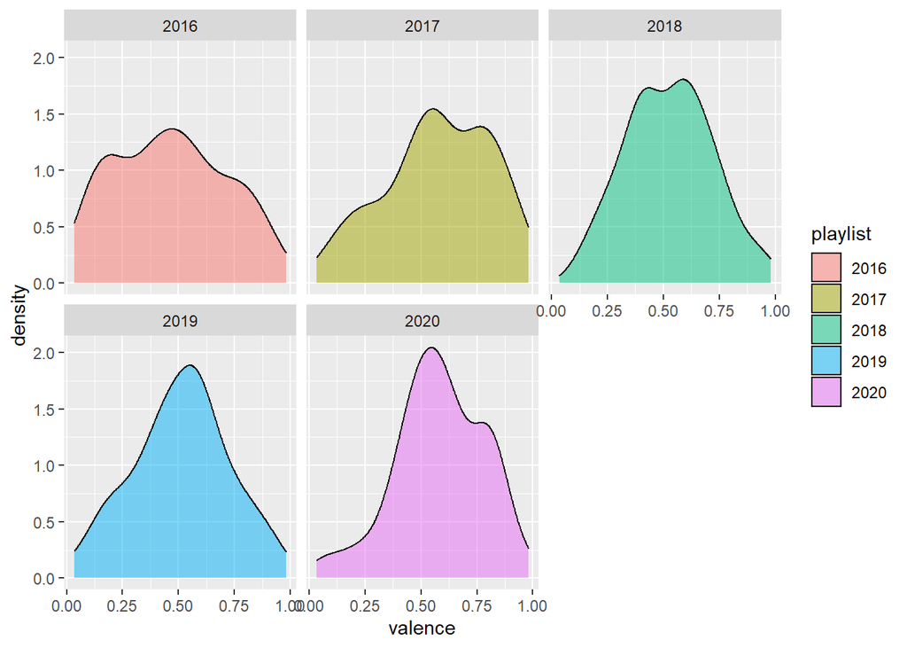

```r
# Looking at the difference in valence
wider_all_playlists |>
  ggplot() +
  aes(x = valence, fill = playlist) +
  geom_density(alpha = 0.5) +
  facet_wrap(~ playlist)
```

Let’s break things down per-year

```r
# Separating things
wide_2020 <- wider_all_playlists |> filter(playlist == "2020")
wide_2019 <- wider_all_playlists |> filter(playlist == "2019")
wide_2018 <- wider_all_playlists |> filter(playlist == "2018")
wide_2017 <- wider_all_playlists |> filter(playlist == "2017")
wide_2016 <- wider_all_playlists |> filter(playlist == "2016")
```

I want to create a similar graph for each variable so let’s get functional

```r
audio_feature_graph <- function(data, audio_feature) {

  # For passing in columns into function
  feature <- sym(audio_feature)

  plot <- data |>
    ggplot() +
    aes(x = !!feature, y = playlist, color = playlist, fill = playlist)

  plot <-
    plot +
    stat_slab(
      size = .5,
      alpha = .2
    ) +
    stat_halfeye(fill = "transparent")

  plot <-
    plot +
    theme_minimal() +
    labs(y = "") +
    theme(
      legend.position = "none",
      plot.title = element_text(hjust = 0.5)
    )

  return(plot)
}
```

Aaaaaaaaand map!

```r
all_audio_features <- c(
  "danceability", "energy", "loudness", "speechiness",
  "acousticness", "liveness",
  "valence", "tempo", "duration_ms"
)

all_plots <- all_audio_features |>
  map(~ audio_feature_graph(wider_all_playlists, .x))
```

Add some description

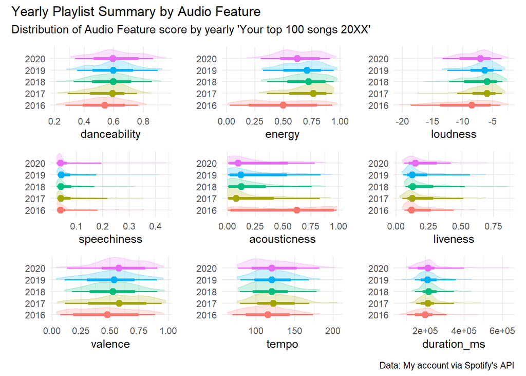

```r
all_plots <-
  wrap_plots(all_plots) +
  plot_annotation(
    title = "Yearly Playlist Summary by Audio Feature",
    subtitle = "Distribution of Audio Feature score by yearly 'Your top 100 songs 20XX'",
    caption = "Data: My account via Spotify's API"
  )

all_plots
```

## Using the `correlation` package

The `correlation` package is apart of `easystats` and allows for easy correlation analysis (go figure)

Let’s look at a correlation matrix

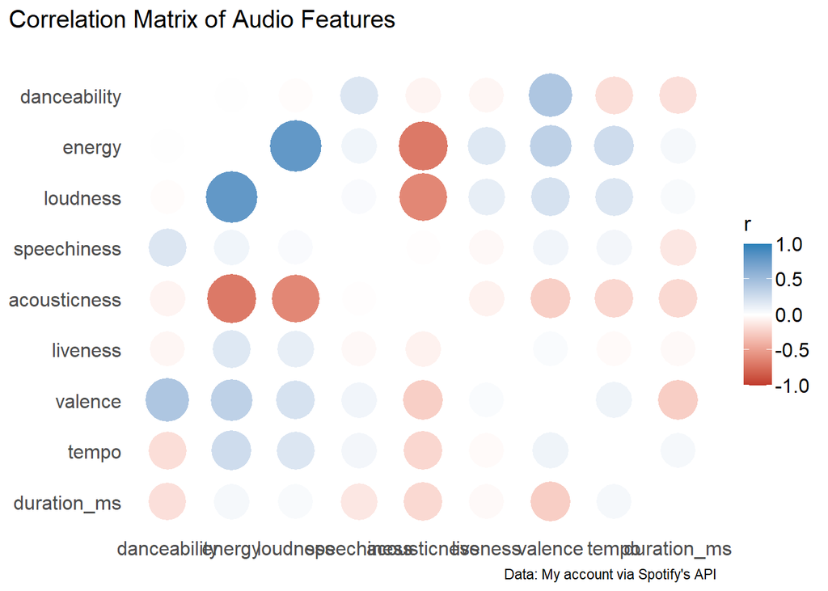

```r
library(correlation)
library(ggraph)

results <- correlation(
  wider_all_playlists,
  select = all_audio_features
)

corr_matrix <- results |>
  summary(redundant = TRUE) |>
  plot() +
  labs(
    title = "Correlation Matrix of Audio Features",
    caption = "Data: My account via Spotify's API"
  )
corr_matrix
```

We can also make a Gaussian Graphical Model (GGM) of our data.

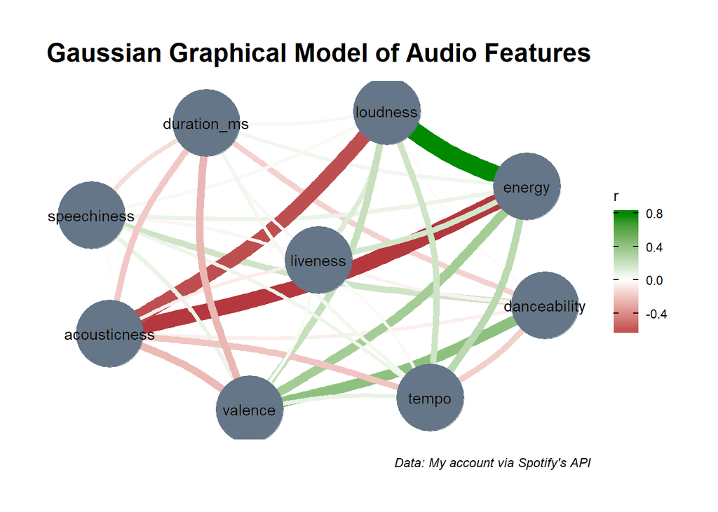

```r
ggm_graph <- results |>
  plot() +
  geom_node_text(label = all_audio_features, color = "black") +
  labs(
    title = "Gaussian Graphical Model of Audio Features",
    caption = "Data: My account via Spotify's API"
  )
ggm_graph
```

## Conclusion

This was a fun little activity to look at how my music taste has changed over time on Spotify.

# Reference

Makowski, D., Ben-Shachar, M. S., Patil, I., & Lüdecke, D. (2019). Methods and Algorithms for Correlation Analysis in R. Journal of Open Source Software, 5(51), 2306. doi:10.21105/joss.02306